# ExtraaLearn Project

```python
# Importance of features in the tree building

print (pd.DataFrame(d_tree_tuned.feature_importances_, columns = ["Imp"], index = X_train.columns).sort_values(by = 'Imp', ascending = False))
```

```
                                   Imp
time_spent_on_website          0.34814
first_interaction_Website      0.32718
profile_completed_Medium       0.23927
age                            0.06389
last_activity_Website Activity 0.02151
print_media_type2              0.00000
digital_media                  0.00000
educational_channels           0.00000
referral                       0.00000
website_visits                 0.00000
age_engagement_interaction     0.00000
current_occupation_Student     0.00000
current_occupation_Unemployed  0.00000
print_media_type1              0.00000
profile_completed_Low          0.00000
page_views_per_visit           0.00000
last_activity_Phone Activity   0.00000
engagement_score               0.00000
```

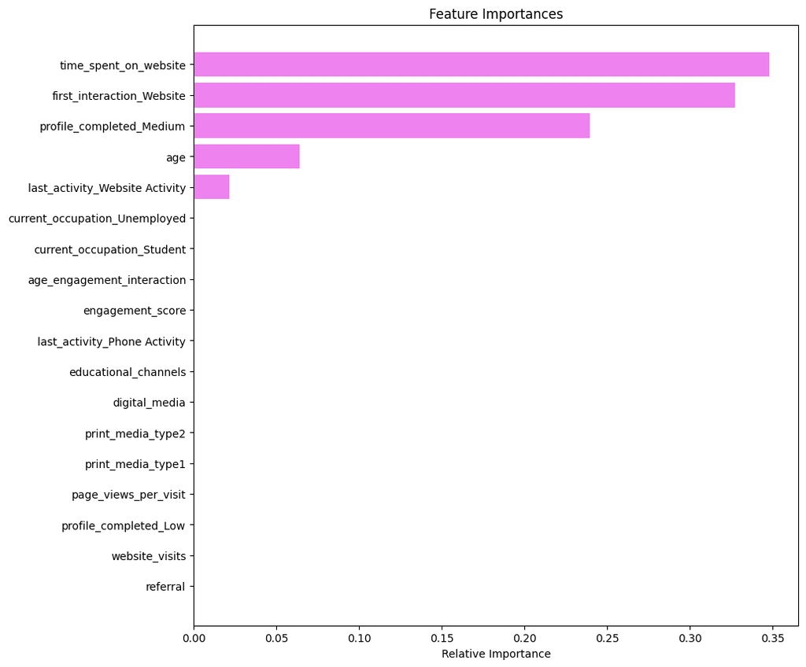

```python
# Plotting the feature importance
importances = d_tree_tuned.feature_importances_

indices = np.argsort(importances)

plt.figure(figsize = (10, 10))

plt.title('Feature Importances')

plt.barh(range(len(indices)), importances[indices], color = 'violet', align = 'center')

plt.yticks(range(len(indices)), [features[i] for i in indices])

plt.xlabel('Relative Importance')

plt.show()
```

Observations:

Time spent on the website and first_interaction_website are the most important features followed by profile_completed, age, and last_activity. The rest of the variables have no impact in this model, while deciding whether a lead will be converted or not.

## Do we need to prune the tree?

Yes, we should prune the tree since some features are not important at all in the decision tree model

```python
from sklearn.model_selection import cross_val_score

# Search for the optimal ccp_alpha value
alpha_values = np.linspace(0.001, 0.02, 50)
mean_scores = []

for ccp_alpha in alpha_values:
    clf = DecisionTreeClassifier(random_state=7, ccp_alpha=ccp_alpha)
    scores = cross_val_score(clf, X_train, y_train, cv=5, scoring='accuracy')
    mean_scores.append(np.mean(scores))

# Find the alpha value with the highest mean accuracy score
optimal_ccp_alpha = alpha_values[np.argmax(mean_scores)]

# Prune the tree using the optimal ccp_alpha
d_tree_pruned = DecisionTreeClassifier(random_state=7, ccp_alpha=optimal_ccp_alpha)
d_tree_pruned.fit(X_train, y_train)
```

```
DecisionTreeClassifier(ccp_alpha=0.0013877551020408164, random_state=7)
```

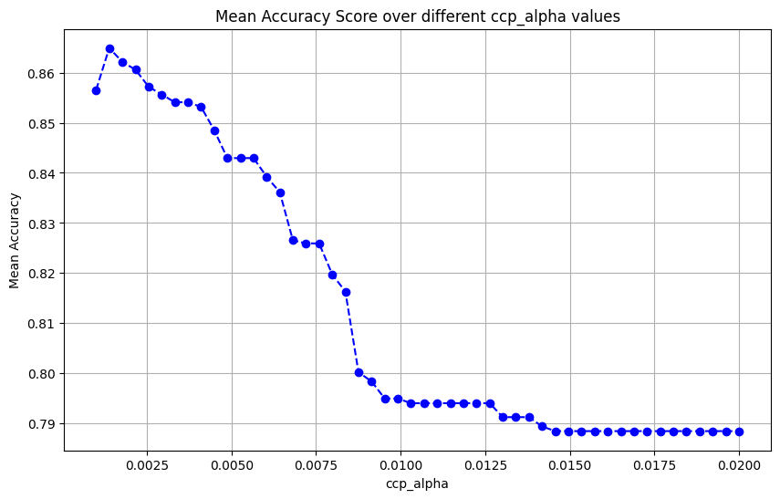

```python
# Plotting the mean accuracy scores over different ccp_alpha values
plt.figure(figsize=(10, 6))
plt.plot(alpha_values, mean_scores, marker='o', linestyle='--', color='b')
plt.title('Mean Accuracy Score over different ccp_alpha values')
plt.xlabel('ccp_alpha')
plt.ylabel('Mean Accuracy')
plt.grid(True)
plt.show()
```

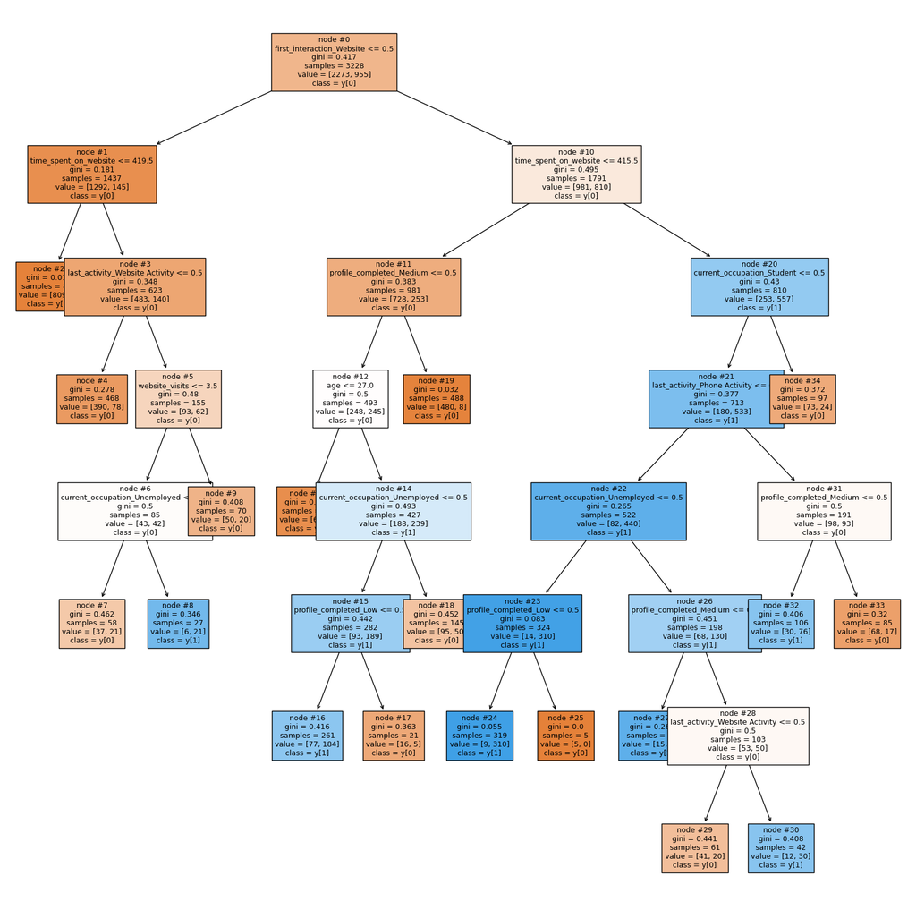

```python
features = list(X.columns)

plt.figure(figsize = (20, 20))

tree.plot_tree(d_tree_pruned, feature_names = features, filled = True, fontsize = 9, node_ids = True, class_names = True)

plt.show()
```